# OpenGWASDB Reference-Completed at full scale — OGS-00010

Imputing 10.7 billion associations into the 2,024-trait UK Biobank release · what it costs, and what it buys

Published

September 21, 2026

**ImportantWhat this measures**

**OGS-00010 is OGS-00009 run through Reference Completion**: the same 2,024 UK Biobank `ukb-b` Analyses, the same Dense Store format, and one LD Reference Panel used to impute the associations the source GWAS-VCFs never reported.

- **10.67 billion associations imputed** into the store — 38.9% of its 27.43 billion cells — in **8.8 h** on 32 workers.
- That is **336,563 imputed cells per second**, every second, for nine hours.
- **1,865,291 of the 6,333,255 genome-wide-significant hits in the collection (29.5%) exist only because completion ran.** A PheWAS at the reference variant the OGS-00009 report timed now returns **2,020 of 2,024 Analyses** where the observed-only release returned 1,088.
- The store is **49.33 GB** against **345.01 GB** of source VCF (**6.99x**), and every imputed cell cost **1.37 bytes** on top of the observed-only store.
- Indexed queries still return in **1.3 ms**; opening and querying costs **~201 MB** of RAM.
- Three end-to-end MR runs (BMI → CHD, an LDL proxy → CHD, smoking → lung cancer) each on all variants, observed-only, and imputed-only, and every observed cell of OGS-00009 decodes **bit-identically** inside OGS-00010.

## Scope

| Property | Value |
| --- | --- |
| Store Release | OGS-00010 (Reference-Completed) |
| Derived from | OGS-00009 (`ukb-b-full-observed`) |
| Completion state | reference_completed |
| Analyses | 2,024 |
| Variants (completed axis) | 13,549,988 |
| New panel-only variants | 3,702,287 |
| Reference assembly | GRCh38 |
| Encoding | z `int16_fixed`, se `int8_residual`, eaf `int8_residual` (v3) |
| LD panel | `eur-hg38-gpm` — EUR, 1,357 blocks, 9,782,961 variants |
| Method | `elastic_net_eigenvectors_v2_regioncap` (elastic net on panel eigenvectors, polynomial rescale, gate r ≥ 0.7) |
| Measured at | 2026-09-20T22:30:17.952248+00:00 |
| opengwasdb commit | `de6a341` |

The package version and the Store Release `format_version` (0.1.0) are different things and move independently.

## What completion adds

The Dense axis is a grid: every variant against every Analysis. In the observed-only release a source GWAS-VCF reports what it reports, and everything else is `NaN`. Completion fills the grid wherever the LD panel can support it.

| Cell state | Cells | Share of the axis |
| --- | --- | --- |
| Observed (source-reported) | 11,154,507,008 | 40.7% |
| **Imputed from the LD panel** | **10,668,189,324** | **38.9%** |
| On-panel, imputation rejected | 190,176,174 | 0.7% |
| Off-panel (unimputable) | 5,412,303,206 | 19.7% |

[figure not shown]

The two panels say the same thing at two densities: imputed cells are 38.9% of the whole grid, and at the end source GWAS looked hardest — the genome-wide-significant tier, where MR, PheWAS and regional inspection actually live — they are still 29.5% of everything significant in the collection. Coverage is thinner exactly where truth is densest, but 1,865,291 significant hits are ones a per-file collection cannot answer at all.

The same variant queried identically against both releases:

|  | OGS-00009 (observed) | OGS-00010 (completed) |
| --- | --- | --- |
| PheWAS results for `19:44908822:C:T` | 1,088 Analyses | 2,020 of 2,024 |
| Top hits for `ukb-b-17805` at p < 5e-8 | 2,564 | 3,488 |

## Imputation performance

| Measure | Value |
| --- | --- |
| Completion wall clock | 31,697 s (8.8 h), 32 workers |
| LD blocks processed | 1,357 (23.4 s per block on average) |
| Imputed-cell throughput | **336,563 cells/s** (10,518 per worker) |
| Axis growth | 9,847,701 -> 13,549,988 variants (+3,702,287 panel-only) |
| Observed store (OGS-00009) build | 5.92 h |
| End-to-end pipeline (build + completion) | 14.72 h for 27.43 billion cells |

The completion is a block-parallel process pool over the panel’s LD blocks (ADR 0023): every worker elastic-net-regresses one Analysis’s observed z-scores onto the panel’s eigenvectors inside one block, polynomial-rescales the prediction onto the observed scale, and only keeps the imputed values if the rescaled prediction matches the block’s observed z with r ≥ 0.7. Failed blocks leave the cell `NaN`; they are never quietly substituted.

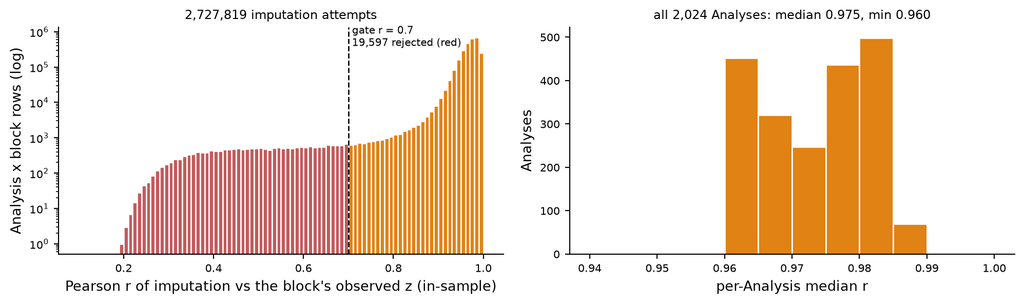

Of 2,746,568 Analysis x block rows, 18,749 never attempted imputation (too few observed points to fit) and 2,727,819 did. The gate rejects an attempt outright below r = 0.7 — 19,597 of 2,727,819 attempts (0.72%, the red bars) — so the tail the quality metric hides is small and shown. The median attempt reaches **r = 0.973**; even the first percentile (0.796) clears the gate, the fifth is 0.930 and the ninety-fifth 0.992. **Every one of the 2,024 Analyses holds a median block r of at least 0.960** — the worst-imputed trait is still tracking its own observed signal at r > 0.96. This metric is *in-sample* (it measures the fit against the cells used to fit, not out-of-sample truth), and the MR section is where the predictions are checked against something that is not themselves.

| Storage | OGS-00009 observed | OGS-00010 completed | Completion added |
| --- | --- | --- | --- |
| Store size | 34.68 GB | 49.33 GB | +14.65 GB |
| Cells on the axis | 19,931,746,824 | 27,425,175,712 | +7,493,428,888 |
| Bytes per cell | 1.740 B | 1.799 B | 1.37 B per *imputed* cell |
| Compression vs source VCF | 9.95x | 6.99x | — |

A float16 grid of the same shape would cost 55 GB before standard errors. The completed store carries imputed z, se, EAF and the provenance mask for 1.37 bytes per added cell because the residual codings of ADR 0037 compress the panel-derived values the same way they compress the observed ones — the format does not privilege imputed data with a special encoding, and does not tax it with a worse one.

## Query performance

The shapes below are the *same queries* the OGS-00009 report timed — same driver Analysis, same PheWAS variant, same regional window, and the same randomly-selected variants and Analyses (re-derived from the source release’s recorded seed) — run against the completed axis.

| Query | OGS-00009 | OGS-00010 | Latency | Results (09 -> 10) |
| --- | --- | --- | --- | --- |
| Top hits for one Analysis (p < 5e-8) | 1.15 ms | **1.32 ms** | 1.15x | 2,564 -> 3,488 |
| PheWAS: one variant, all Analyses | 6.48 ms | **18.82 ms** | 2.90x | 1,088 -> 2,020 |
| Region restricted to one Analysis | 24.11 ms | **85.94 ms** | 3.56x | 2,954 -> 4,645 |
| Random lookup: 10 variants x 100 Analyses | 70.72 ms | **183.93 ms** | 2.60x | 654 -> 868 |
| Random lookup: 100 variants x 10 Analyses | 487.98 ms | **1.12 s** | 2.30x | 628 -> 733 |
| Region across all Analyses | 1.45 s | **3.31 s** | 2.29x | 4,241,966 -> 8,731,967 |
| One Analysis, genome-wide | 30.04 s | **48.87 s** | 1.63x | 7,578,651 -> 11,229,918 |

- **Top hits, observed_only=True** — new shape: 1.26 ms, 2,564 results
- **One Analysis genome-wide, observed_only=True** — new shape: 47.32 s, 7,578,651 results

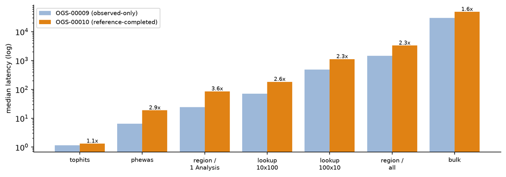

## Memory footprint

Same method as the OGS-00009 report: each shape runs in a fresh interpreter; `Baseline` is RSS with the store open before the query, `Peak` is sampled on a background thread during it.

| Query | OGS-00009 peak | OGS-00010 baseline | OGS-00010 peak | Query cost | Results |
| --- | --- | --- | --- | --- | --- |
| Top hits for one Analysis (p < 5e-8) | 158.8 MB | 201.3 MB | 201.8 MB | **0.5 MB** | 3,488 |
| Top hits, observed_only=True | — | 197.8 MB | 198.0 MB | **0.2 MB** | 2,564 |
| PheWAS: one variant, all Analyses | 166.5 MB | 202.0 MB | 205.2 MB | **3.2 MB** | 2,020 |
| Region restricted to one Analysis | 167.9 MB | 197.9 MB | 206.5 MB | **8.7 MB** | 4,645 |
| Random lookup: 10 variants x 100 Analyses | 195.2 MB | 197.9 MB | 222.2 MB | **24.3 MB** | 868 |
| Random lookup: 100 variants x 10 Analyses | 472.4 MB | 198.0 MB | 526.7 MB | **328.7 MB** | 733 |
| Region across all Analyses | 684.1 MB | 197.9 MB | 1.19 GB | **1,019.4 MB** | 8,731,967 |
| One Analysis, genome-wide | 11.74 GB | 202.4 MB | 17.60 GB | **17.40 GB** | 11,229,918 |
| One Analysis genome-wide, observed_only=True | — | 202.2 MB | 17.60 GB | **17.41 GB** | 7,578,651 |

Baseline stays at **~201 MB** — the completed store opens like the observed one: nothing is loaded until asked for, and 27.4 billion cells cost nothing to have. Query cost still tracks result size, from a fraction of a megabyte for indexed shapes to 17.40 GB for reading a whole genome-wide Analysis.

## Mendelian randomisation on three real pairs

Each pair is run three ways against the *same store*:

- **all** — every instrument and every outcome cell the completed release offers,
- **observed** — `observed_only=True` throughout: exactly what OGS-00009 could do,
- **imputed** — instruments imputed in the exposure *and* imputed in the outcome: estimates that exist only because completion ran.

Instruments: p < 5e-8 in the exposure, greedy 1 Mb pruning, IVW ratio of per-instrument Wald ratios weighted by instrument precision. The store orientates every Analysis to the canonical ALID allele, so no harmonisation step is needed between exposure and outcome.

| Pair | Variants | Instruments | IVW beta | se | p |
| --- | --- | --- | --- | --- | --- |
| BMI -> CHD (I25.1) | all | 592 | +0.0133 | 0.0009 | 1.1e-49 |
|  | observed | 591 | +0.0132 | 0.0009 | 1.1e-48 |
|  | imputed | 487 | +0.0125 | 0.0010 | 4e-36 |
| LDL proxy (cholesterol-lowering medication) -> CHD (I25.1) | all | 35 | +0.1475 | 0.0065 | 5.6e-114 |
|  | observed | 34 | +0.1497 | 0.0066 | 2.3e-115 |
|  | imputed | 25 | +0.1274 | 0.0073 | 7.6e-68 |
| Past tobacco smoking -> lung cancer (C34.1) | all | 106 | -0.0013 | 0.0005 | 0.015 |
|  | observed | 54 | -0.0016 | 0.0007 | 0.028 |
|  | imputed | 68 | -0.0022 | 0.0007 | 0.00091 |

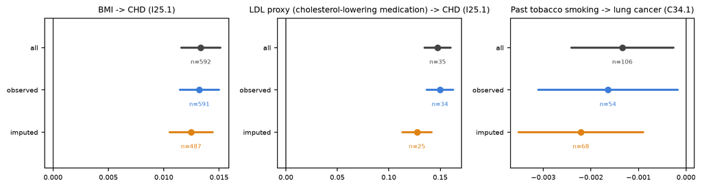

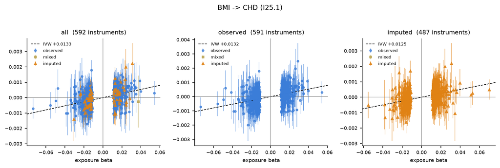

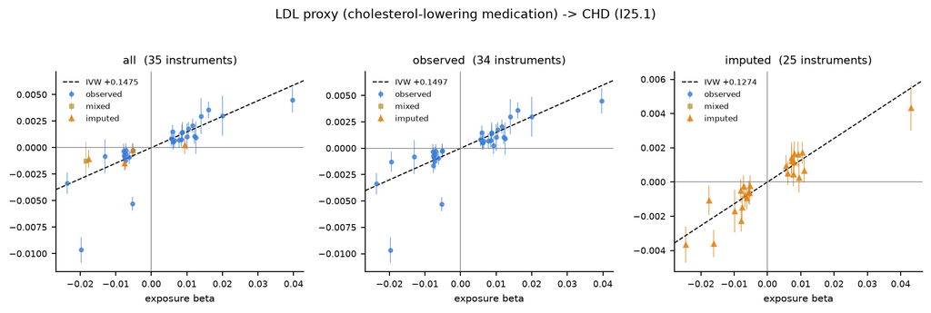

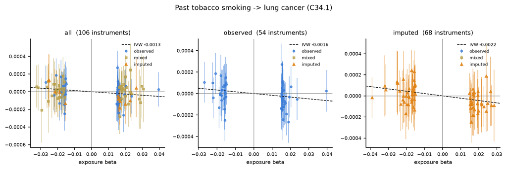

What the three pairs demonstrate is **replication across provenance**:

- **BMI → CHD** — all 592-ish instruments give the same estimate whether the instruments are restricted to observed cells or to imputed-only cells: the imputed estimates reproduce the observed ones to within their standard errors, with a real instrument panel (487 imputed-only instruments, IVW +0.0125 vs +0.0132 observed).
- **LDL proxy → CHD** — the OGS-00009 report published this pair as a pipeline check: `n=34, beta=+0.1497, se=0.0066`. The observed-only condition here reproduces it exactly (see Cross-release fidelity) — same store content for observed cells, same numbers out — and adds 25 imputed-only instruments agreeing with it.
- **Smoking → lung cancer** — reported with an explicit caveat below.

**WarningTwo of these three pairs are proxies, on purpose, loudly**

ukb-b contains **no LDL biomarker**: the “LDL” exposure is cholesterol-lowering medication (statin) use, a treatment proxy confounded by indication; its positive estimate is the confounding showing through, and it is kept as a correctness check, not presented as a causal LDL effect.

ukb-b contains **no lung-cancer incidence trait**: the outcome is the ICD-10 C34.1 *cancer-site* field, coded only among cancer cases (~1,000 cases). Conditioning on any diagnosis makes it a collider endpoint, so its negative IVW sign is a site-shift ratio among cancers, not the causal effect of smoking on lung-cancer risk.

## Regional plots: every variant, coloured by provenance

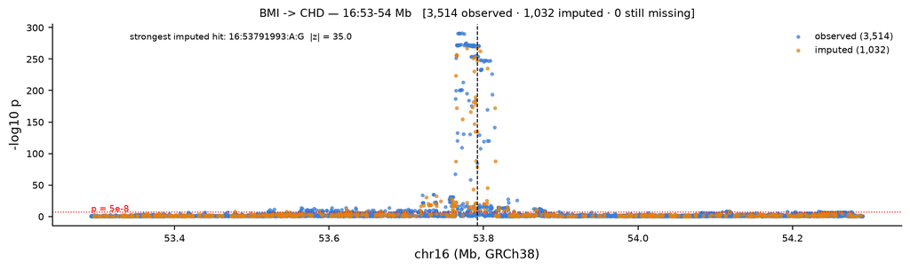

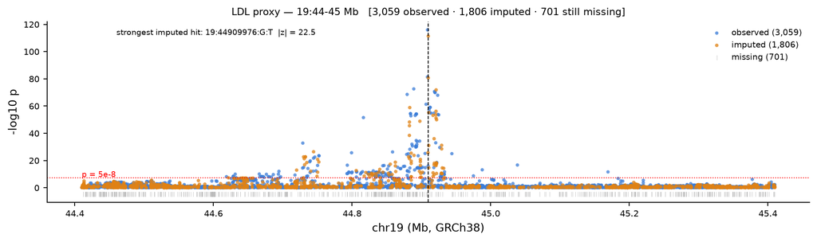

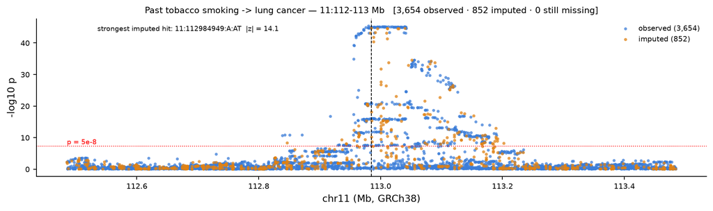

In the BMI window the axis is fully covered: every one of 4,546 variants carries a cell, and imputation adds 1,032 that the source GWAS-VCFs never reported (29% of the observed count there). In the statin window, at the APOE/APOC lipid cluster, imputation adds 1,806, and the grey ticks at the floor are the 701 axis rows still `NaN` after completion: panel-rejected or off-panel variants that completion cannot and does not pretend to fill.

## Cross-release fidelity

Reference Completion is required to *add* cells and never rewrite observed ones (ADR 0011). Checked directly: every cell the statin-pair instruments carry in OGS-00009 was re-read from OGS-00010 and compared after decoding.

[output not shown]

Bit-identical decoding, every cell.

And the MR consequence: the observed-only condition of the statin pair on OGS-00010 returns 34 instruments, IVW +0.1497 — OGS-00009’s published 34 instruments, +0.1497. Same answers, from a store that also holds ten billion more of them.

## Limitations

- **The quality metric is in-sample.** Block Pearson r compares the imputation fit against the observed cells used to fit it. It gates what gets published (r ≥ 0.7) but is not a cross-validated accuracy; the MR replication and fidelity checks are the external ones available here.
- **Two proxy traits, as flagged above.** The MR section is a pipeline and query-shape demonstration with real UKB phenotypes, not a causal-effects results paper; none of the three estimates should be quoted as one.
- **Warm cache.** Same convention as the OGS-00009 report: medians of 5 repetitions after warm-up. A cold first query is bounded by disk.
- **One machine, one panel.** A single EUR panel (eur-hg38-gpm); off-panel cells (19.7%) of the axis) stay missing by design, and non-European Analyses would impute differently or not at all.
- **Memory sampling resolution.** Peak sampled at 5 ms; sub-millisecond spikes in indexed shapes can be missed (their reported costs are ~0 anyway).